# Machine Learning Fundamental(sklearn)

### Prepare the Data for Machine Learning Algorithms

Write function to automate the process

```python
X = strat_train_set.drop('median_house_value', axis='columns')
y = strat_train_set['median_house_value'].copy()
```

#### Data Cleaning

fix missing value with these 3 options

1. Get rid of the corresponding districts.
2. Get rid of the whole attribute.
3. Set the values to some value (zero, the mean, the median, etc.).

Or Sklearn provide useful Imputer to impute and store value in statistics_ instance

```python
# housing.dropna(subset=["total_bedrooms"]) # option 1
# housing.drop("total_bedrooms", axis=1) # option 2
# median = housing["total_bedrooms"].median() # option 3
# housing["total_bedrooms"].fillna(median, inplace=True)
```

```python
from sklearn.impute import SimpleImputer
imputer = SimpleImputer(strategy='median')

# have to remove string variable of indices first
housing_num = X.drop('ocean_proximity',axis='columns')
#then fit
imputer.fit(housing_num)
#print store median for each features
print(imputer.statistics_)
print(housing_num.median())
```

```
[-118.51     34.26     29.     2119.5     433.     1164.      408.
    3.5409]
longitude             -118.5100
latitude                34.2600
housing_median_age      29.0000
total_rooms           2119.5000
total_bedrooms         433.0000
population            1164.0000
households             408.0000
median_income            3.5409
dtype: float64
```

```python
#then use train impute to fit the X(indices)
X = imputer.fit_transform(housing_num) # just return array of number
# or
housing_transfrom = pd.DataFrame(X, columns=housing_num.columns , index = housing_num.index) # return dataframe
housing_transfrom.isnull().any()
```

```
longitude             False
latitude              False
housing_median_age    False
total_rooms           False
total_bedrooms        False
population            False
households            False
median_income         False
dtype: bool
```

#### Handling Text and Categorical Attributes

```python
print(set(housing_ex['ocean_proximity'].values))
ocean_prox = housing_ex[['ocean_proximity']]
housing_ex[['ocean_proximity']].head(5)
```

```
{'ISLAND', '<1H OCEAN', 'NEAR OCEAN', 'NEAR BAY', 'INLAND'}
```

|  | ocean_proximity |
| --- | --- |
| 17606 | <1H OCEAN |
| 18632 | <1H OCEAN |
| 14650 | NEAR OCEAN |
| 3230 | INLAND |
| 3555 | <1H OCEAN |

```python
# use one-hot encoding because these features are not ordinal or label
from sklearn.preprocessing import OneHotEncoder
encoder = OneHotEncoder()
dummy_ocean = encoder.fit_transform(ocean_prox)
dummy_ocean # this will return in scipy sparse matrix to save memory
# to convert it to array to visualize use toarray()
print(encoder.categories_)
print(dummy_ocean.toarray())
pd.DataFrame(dummy_ocean.toarray(), columns=encoder.categories_).head(4)
```

```
[array(['<1H OCEAN', 'INLAND', 'ISLAND', 'NEAR BAY', 'NEAR OCEAN'],
      dtype=object)]
[[1. 0. 0. 0. 0.]
 [1. 0. 0. 0. 0.]
 [0. 0. 0. 0. 1.]
 ...
 [0. 1. 0. 0. 0.]
 [1. 0. 0. 0. 0.]
 [0. 0. 0. 1. 0.]]
```

|  | <1H OCEAN | INLAND | ISLAND | NEAR BAY | NEAR OCEAN |
| --- | --- | --- | --- | --- | --- |
| 0 | 1.0 | 0.0 | 0.0 | 0.0 | 0.0 |
| 1 | 1.0 | 0.0 | 0.0 | 0.0 | 0.0 |
| 2 | 0.0 | 0.0 | 0.0 | 0.0 | 1.0 |
| 3 | 0.0 | 1.0 | 0.0 | 0.0 | 0.0 |

Create automatic process to add extra features of 'income_cat, rooms_per_household, population_per_household'

```python
from sklearn.base import BaseEstimator, TransformerMixin

# column index
rooms_ix, bedrooms_ix, population_ix, households_ix = 3, 4, 5, 6

class CombinedAttributesAdder(BaseEstimator, TransformerMixin):
    def __init__(self, add_bedrooms_per_room = True): # parameter option to add bedroom/house
        self.add_bedrooms_per_room = add_bedrooms_per_room
    def fit(self, X, y=None):
        return self  # nothing else to do
    def transform(self, X):
        rooms_per_household = X[:, rooms_ix] / X[:, households_ix] #add room/house
        population_per_household = X[:, population_ix] / X[:, households_ix] #add pop/house
        if self.add_bedrooms_per_room:
            bedrooms_per_room = X[:, bedrooms_ix] / X[:, rooms_ix]
            return np.c_[X, rooms_per_household, population_per_household,
                         bedrooms_per_room]
        else:
            return np.c_[X, rooms_per_household, population_per_household]

attr_adder = CombinedAttributesAdder(add_bedrooms_per_room=False)
housing_extra_attribs = attr_adder.transform(housing.values)
```

```python
housing_extra_attribs = pd.DataFrame(
    housing_extra_attribs,
    columns=list(housing.columns)+["rooms_per_household", "population_per_household"],
    index=housing.index)
housing_extra_attribs.head()
```

|  | longitude | latitude | housing_median_age | total_rooms | total_bedrooms | population | households | median_income | median_house_value | ocean_proximity | income_cat | rooms_per_household | population_per_household |
| --- | --- | --- | --- | --- | --- | --- | --- | --- | --- | --- | --- | --- | --- |
| 0 | -122.23 | 37.88 | 41 | 880 | 129 | 322 | 126 | 8.3252 | 452600 | NEAR BAY | 5 | 6.98413 | 2.55556 |
| 1 | -122.22 | 37.86 | 21 | 7099 | 1106 | 2401 | 1138 | 8.3014 | 358500 | NEAR BAY | 5 | 6.23814 | 2.10984 |
| 2 | -122.24 | 37.85 | 52 | 1467 | 190 | 496 | 177 | 7.2574 | 352100 | NEAR BAY | 5 | 8.28814 | 2.80226 |
| 3 | -122.25 | 37.85 | 52 | 1274 | 235 | 558 | 219 | 5.6431 | 341300 | NEAR BAY | 4 | 5.81735 | 2.54795 |
| 4 | -122.25 | 37.85 | 52 | 1627 | 280 | 565 | 259 | 3.8462 | 342200 | NEAR BAY | 3 | 6.28185 | 2.18147 |

##### Feature Scaling

1. normalization from sklearn import $MinMaxScaler$ -> value will be between [0,1]
2. standardization from sklearn import $StandardScaler$ -> value will stay close to 0 as mean

```python
from sklearn.preprocessing import MinMaxScaler
from sklearn.preprocessing import StandardScaler

scaler = StandardScaler()
scaler.fit_transform(housing_num)[:2]
```

```
array([[-1.15604281,  0.77194962,  0.74333089, -0.49323393, -0.44579584,
        -0.63621141, -0.42069842, -0.61493744],
       [-1.17602483,  0.6596948 , -1.1653172 , -0.90896655, -1.03462064,
        -0.99833135, -1.02222705,  1.33645936]])
```

#### Transformation Pipelines

Pipeline class to help with such sequences of transformations, in this case impute missing value, create new features(add), scaler

```python
from sklearn.pipeline import Pipeline

num_pipeline = Pipeline([
        ('imputer', SimpleImputer(strategy="median")),
        ('attribs_adder', CombinedAttributesAdder()),
        ('std_scaler', StandardScaler()),
    ])

housing_num_tr = num_pipeline.fit_transform(housing_num)
housing_num_tr.shape
```

```
(16512, 11)
```

However, we can deal with number and categorical features together with appropriate transformation with $ColumnTransformer$

```python
Xtrain = strat_train_set.drop("median_house_value", axis=1)
```

```python
from sklearn.compose import ColumnTransformer
# define which column is numeric and which is cateforical
num_features = list(housing_num.columns)
cat_features = ['ocean_proximity']
#fit where each tuple contains a name, a transformer, and a list of names (or indices) of columns that the transformer should be applied to
full_pipeline = ColumnTransformer([ ('num' , num_pipeline , num_features),
                                    ('cat' , OneHotEncoder(), cat_features)])
housing_prepared = full_pipeline.fit_transform(Xtrain) #fit on all training set
housing_prepared[:1]
```

```
array([[-1.15604281,  0.77194962,  0.74333089, -0.49323393, -0.44543821,
        -0.63621141, -0.42069842, -0.61493744, -0.31205452, -0.08649871,
         0.15531753,  1.        ,  0.        ,  0.        ,  0.        ,
         0.        ]])
```

### Select and Train a Model

```python
# strat with lienar regression
from sklearn.linear_model import LinearRegression
lin_reg = LinearRegression()
lin_reg.fit(housing_prepared, y) #fit(X,y)
y_pred = lin_reg.predict(housing_prepared)
#Try predict something
#set up sample data
some_data = Xtrain.iloc[:5]
target = y.iloc[:5]
some_data_prepared = full_pipeline.transform(some_data)
print("Predict:", lin_reg.predict(some_data_prepared))
print("Labels:", list(target))
# see that some value deviate alot (huge error)
```

```
Predict: [210644.60459286 317768.80697211 210956.43331178  59218.98886849
 189747.55849879]
Labels: [286600.0, 340600.0, 196900.0, 46300.0, 254500.0]
```

```python
# evaluate with RMSE
from sklearn.metrics import mean_squared_error
mse = mean_squared_error(y,y_pred)
lin_rmse = np.sqrt(mse)
lin_rmse
```

```
68628.19819848923
```

clearly not a great score: most districts’ median_housing_values range between USD 120,000 and 265,000 so a typical prediction error of USD 68,628 is not very satisfying

```python
# let's try more complex model
from sklearn.tree import DecisionTreeRegressor
tree_reg = DecisionTreeRegressor()
tree_reg.fit(housing_prepared,y)
#predict
y_pred_tree = tree_reg.predict(housing_prepared)
#let evaluate
mse = mean_squared_error(y,y_pred_tree)
tree_rmse = np.sqrt(mse)
tree_rmse
```

```
0.0
```

Clearly non error on training set means the model overfiting the data let's try avoid that by Cross Validation

#### Better Evaluation Using Cross-Validation

```python
from sklearn.model_selection import cross_val_score
scores = cross_val_score(tree_reg,X = housing_prepared,y= y,
                        scoring='neg_mean_squared_error', cv= 10) #scoring for mse
tree_rmse_cv_score  = np.sqrt(-scores)
# lets see result
tree_rmse_cv_score , 'Mean is',tree_rmse_cv_score.mean()
```

```
(array([69851.19441221, 66987.98404985, 71802.31553176, 70020.3409888 ,
        70212.19694296, 73521.49295621, 70465.46188048, 71263.50725771,
        75354.55950104, 70473.20736847]), 'Mean is', 70995.22608894986)
```

```python
#do cross validation for Linear regression as well to compare
scores = cross_val_score(lin_reg, X = housing_prepared,y= y,
                        scoring='neg_mean_squared_error', cv= 10) #scoring for mse
lin_rmse_cv_score  = np.sqrt(-scores)
# lets see result
'Mean is',lin_rmse_cv_score.mean()
```

```
('Mean is', 69052.46136345083)
```

the Decision Tree model is overfitting so badly that it performs worse than the Linear Regression model.

```python
#let try random forrest
from sklearn.ensemble import RandomForestRegressor
forrest_reg = RandomForestRegressor()
forrest_reg.fit(housing_prepared,y)
# evaluation
scores = cross_val_score(forrest_reg,housing_prepared,y,
                        scoring= 'neg_mean_squared_error', cv = 10)
forrest_rmse = np.sqrt(-scores)
'Mean is',forrest_rmse.mean()
```

```
('Mean is', 50320.6866084904)
```

The goal is to shortlist a few (two to five) promising models by try many different models

### Fine-Tune model

#### 1. Grid Search

```python
from sklearn.model_selection import GridSearchCV
#set param to experiment
param_grid = [{'n_estimators': [80,90,100], 'max_features': [6,7,8]},
                {'bootstrap': [False], 'n_estimators': [3, 10], 'max_features': [2, 3, 4]},]
forest_reg = RandomForestRegressor()
#grid search
grid_search = GridSearchCV(forest_reg,param_grid,
                           scoring = 'neg_mean_squared_error',return_train_score=True)
grid_search.fit(housing_prepared,y)
# return the parameter with best model
grid_search.best_params_
```

```
{'max_features': 6, 'n_estimators': 100}
```

```python
#or return the best estimator to use for predict and so on (already fitted)
grid_search.best_estimator_
```

```
RandomForestRegressor(bootstrap=True, ccp_alpha=0.0, criterion='mse',
                      max_depth=None, max_features=6, max_leaf_nodes=None,
                      max_samples=None, min_impurity_decrease=0.0,
                      min_impurity_split=None, min_samples_leaf=1,
                      min_samples_split=2, min_weight_fraction_leaf=0.0,
                      n_estimators=100, n_jobs=None, oob_score=False,
                      random_state=None, verbose=0, warm_start=False)
```

```python
result = grid_search.cv_results_
pd.DataFrame(np.sqrt(-1*result['mean_test_score']),
             index =result['params'] ,
             columns=['RMSE'])

# or pd.DataFrame(grid_search.cv_results_) to see everything in df
```

|  | RMSE |
| --- | --- |
| {'max_features': 6, 'n_estimators': 80} | 49275.517073 |
| {'max_features': 6, 'n_estimators': 90} | 49367.590565 |
| {'max_features': 6, 'n_estimators': 100} | 49245.343126 |
| {'max_features': 7, 'n_estimators': 80} | 49415.887302 |
| {'max_features': 7, 'n_estimators': 90} | 49365.246380 |
| {'max_features': 7, 'n_estimators': 100} | 49430.472993 |
| {'max_features': 8, 'n_estimators': 80} | 49528.469466 |
| {'max_features': 8, 'n_estimators': 90} | 49448.956052 |
| {'max_features': 8, 'n_estimators': 100} | 49336.719701 |
| {'bootstrap': False, 'max_features': 2, 'n_estimators': 3} | 62680.157547 |
| {'bootstrap': False, 'max_features': 2, 'n_estimators': 10} | 54655.613654 |
| {'bootstrap': False, 'max_features': 3, 'n_estimators': 3} | 59719.798283 |
| {'bootstrap': False, 'max_features': 3, 'n_estimators': 10} | 52777.766370 |
| {'bootstrap': False, 'max_features': 4, 'n_estimators': 3} | 59748.350978 |
| {'bootstrap': False, 'max_features': 4, 'n_estimators': 10} | 51787.020212 |

#### 2. Randomize Search

prefer randomize search when number of combination is large

```python
from sklearn.model_selection import RandomizedSearchCV
from scipy.stats import randint

param_distribs = {
        'n_estimators': randint(low=1, high=200),
        'max_features': randint(low=1, high=8),
    }

forest_reg = RandomForestRegressor(random_state=42)
rnd_search = RandomizedSearchCV(forest_reg, param_distributions=param_distribs,
                                n_iter=10, cv=5, scoring='neg_mean_squared_error', random_state=42)
rnd_search.fit(housing_prepared,y)
#see result
cvres = rnd_search.cv_results_
for mean_score, params in zip(cvres["mean_test_score"], cvres["params"]):
    print(np.sqrt(-mean_score), params)
```

```
49150.70756927707 {'max_features': 7, 'n_estimators': 180}
51389.889203389284 {'max_features': 5, 'n_estimators': 15}
50796.155224308866 {'max_features': 3, 'n_estimators': 72}
50835.13360315349 {'max_features': 5, 'n_estimators': 21}
49280.9449827171 {'max_features': 7, 'n_estimators': 122}
50774.90662363929 {'max_features': 3, 'n_estimators': 75}
50682.78888164288 {'max_features': 3, 'n_estimators': 88}
49608.99608105296 {'max_features': 5, 'n_estimators': 100}
50473.61930350219 {'max_features': 3, 'n_estimators': 150}
64429.84143294435 {'max_features': 5, 'n_estimators': 2}
```

### Evaluate Your System on the Test Set

```python
final_model = grid_search.best_estimator_

X_test = strat_test_set.drop("median_house_value", axis=1)
y_test = strat_test_set["median_house_value"].copy()

X_test_prepared = full_pipeline.transform(X_test)
final_predictions = final_model.predict(X_test_prepared)

final_mse = mean_squared_error(y_test, final_predictions)
final_rmse = np.sqrt(final_mse)
final_rmse
```

```
46817.07039605737
```

```python
# can also do 95 confidence interval for RMSE
from scipy import stats

confidence = 0.95
squared_errors = (final_predictions - y_test) ** 2
np.sqrt(stats.t.interval(confidence, len(squared_errors) - 1,
                         loc=squared_errors.mean(),
                         scale=stats.sem(squared_errors)))
```

```
array([44862.82835978, 48692.94397035])
```

### Deployment, Monitor, and Maintain Your System

#### Deployment options

1. save the trained Scikit-Learn model (e.g., using joblib), including the full preprocessing and prediction pipeline, then load this trained model within your production environment and use it to make predictions by calling its predict() method
   - embeded model with in the web application. When user take action, this will send a query along with data to web server then forward to web application. Then model.predict()
   - wrap the model within a dedicated web service that your web application can query through a REST API. This makes it easier to upgrade your model to new versions without interrupting the main application. It also simplifies scaling, since you can start as many web services as needed and load-balance the requests coming from your web application across these web services.
2. Deploy model on the cloud,ie Google Cloud AI Platform. Just save your model using joblib and upload it to Google Cloud Storage (GCS), then head over to Google Cloud AI Platform and create a new model version, pointing it to the GCS file. It take JSON requests containing the input data (e.g., of a district) and returns JSON responses containing the predictions. You can then use this web service in your website

#### Monitor model performance

**Automate process by**  
Collect fresh data regularly and label it (e.g., using human raters).

Write a script to train the model and fine-tune the hyperparameters automatically. This script could run automatically, for example every day or every week, depending on your needs.

Write another script that will evaluate both the new model and the previous model on the updated test set, and deploy the model to production if the performance has not decreased (if it did, make sure you investigate why)

## Chapter 3. Classification

```python
#import data set
from sklearn.indicess import fetch_openml
mnist = fetch_openml('mnist_784', version =1)
mnist.keys()
```

```
dict_keys(['data', 'target', 'frame', 'feature_names', 'target_names', 'DESCR', 'details', 'categories', 'url'])
```

```python
X , y = mnist['data'], mnist['target']
X.shape, y.shape
```

```
((70000, 784), (70000,))
```

```python
# target is a number range from 0-9
# and X is pixel intensity of 28*28 = 784 each one from 0(white) to 255(black)
set(y)
```

```
{'0', '1', '2', '3', '4', '5', '6', '7', '8', '9'}
```

```
4
```

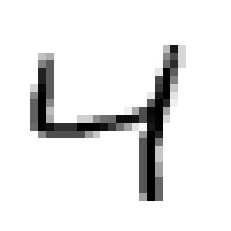

```python
import matplotlib as mpl
import matplotlib.pyplot as plt
print(y[2])

some_digit = X[2]
some_digit_print = some_digit.reshape(28,28) # reshape into 28 x 28
plt.imshow(some_digit_print,cmap = 'binary')
plt.axis('off')
plt.show(); #image show
```

```python
# see that target variable is in str. Lets change them to numeric
print(type(y[0]))
y = y.astype(np.uint8)
```

```
<class 'str'>
```

```python
# split training and test set
X_train, X_test, y_train, y_test = X[:60000], X[60000:], y[:60000], y[60000:]
```

### Training a Binary Classifier

let simplify problem to where this is number 5 or not for binary classifier (5 and not5)

```python
y_train_5 = (y_train == 5) # only True and False
y_test_5 = (y_test == 5)
```

```python
# try with Stochastic Gradient Descent(SGD) classifier, using Scikit-Learn’s SGDClassifier class
from sklearn.linear_model import SGDClassifier
sgd_clf = SGDClassifier(random_state=42)
sgd_clf.fit(X_train, y_train_5)
#see result from method
sgd_clf.score(X_train,y_train_5)
```

```
0.9522666666666667
```

```python
from sklearn.linear_model  import LogisticRegression # try logistic
lg = LogisticRegression(random_state=42)
lg.fit(X_train,y_train_5)
# result
lg.score(X_train,y_train_5)
```

```
0.9778166666666667
```

### Evaluate Classification performance

#### 1. Measuring Accuracy Using Cross-Validation

```python
from sklearn.model_selection import cross_val_score
cross_val_score(sgd_clf,X_train,y_train_5,cv = 3 ,scoring='accuracy')
```

```
array([0.95035, 0.96035, 0.9604 ])
```

```python
cross_val_score(lg,X_train,y_train_5,cv = 3 ,scoring='accuracy')
```

```
array([0.97525, 0.9732 , 0.9732 ])
```

```python
# implement Stratified sampling for cross-validation instead of simple random
from sklearn.model_selection import StratifiedKFold
from sklearn.base import clone

skK = StratifiedKFold(n_splits=3, random_state=None)

for train_index, test_index in skK.split(X_train, y_train_5):
    clone_clf = clone(sgd_clf)
    X_train_K = X_train[train_index]
    y_train_K = y_train_5[train_index]
    X_test_fold = X_train[test_index]
    y_test_fold = y_train_5[test_index]

    clone_clf.fit(X_train_K, y_train_K)
    y_pred = clone_clf.predict(X_test_fold)
    n_correct = sum(y_pred == y_test_fold)
    print(n_correct / len(y_pred))
```

```
0.95035
0.96035
0.9604
```

```python
# but even base Estimator that guess non 5 for all get 90% accuracy because of unbalance 5 is around 10% of data
from sklearn.base import BaseEstimator
class Never5Classifier(BaseEstimator):
    def fit(self, X, y=None):
        pass
    def predict(self, X):
        return np.zeros((len(X), 1), dtype=bool)

never_5_clf = Never5Classifier()
cross_val_score(never_5_clf, X_train, y_train_5, cv=3, scoring="accuracy")
```

```
array([0.91125, 0.90855, 0.90915])
```

#### 2.Confusion Matrix

```python
# cross_val_predict() performs K-fold crossvalidation, and returns the predictions made on each test fold.
from sklearn.model_selection import cross_val_predict
y_train_pred = cross_val_predict(sgd_clf, X_train, y_train_5, cv=3)
```

```python
from sklearn.metrics import confusion_matrix
confusion_matrix(y_train_5 , y_train_pred )
```

```
array([[53892,   687],
       [ 1891,  3530]], dtype=int64)
```

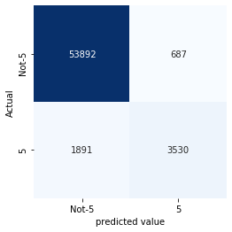

```python
mat = confusion_matrix(y_train_5,y_train_pred )

labels= ['Not-5','5']
sns.heatmap(mat, square=True, annot=True, cbar=False,
            cmap=plt.cm.Blues, # set theme
            fmt='g', # set no truncate number
            xticklabels=labels,
            yticklabels=labels)
plt.xlabel('predicted value')
plt.ylabel('Actual');
```

#### 3.Precision and recall , F1 score

precision : TP over (TP+FP) , % correct of all predict  
Recall : TP over (TP+FN) , % correct of all actual

```python
from sklearn.metrics import precision_score, recall_score
'Precision score',precision_score(y_train_5, y_train_pred) , 'recall', recall_score(y_train_5, y_train_pred)
```

```
('Precision score', 0.8370879772350012, 'recall', 0.6511713705958311)
```

```python
print( 'Comapre with manual calcualte ',3530/(3530+687) , 3530/(3530+1891))
```

```
Comapre with manual calcualte  0.8370879772350012 0.6511713705958311
```

```python
#F1 score is harmonic mean of precision and recall (give much more weight to low value)
from sklearn.metrics import f1_score
f1_score(y_train_5, y_train_pred)
```

```
0.7325171197343846
```

```python
y_scores = cross_val_predict(sgd_clf, X_train, y_train_5, cv=3,
method="decision_function")
```

##### Precision and recall trade-off

Depend on project which one your value more  
Plot to choose precision and recall that coresponding to each threshold

```python
# return all combination of precision and recall that corresponding to each threshold
from sklearn.metrics import precision_recall_curve
precisions, recalls, thresholds = precision_recall_curve(y_train_5, y_scores)
```

Suppose you aim for 90% precision, then find threshold and recall for 90% precision

```python
# calculate
threshold_90_precision = thresholds[np.argmax(precisions >= 0.90)]
recall_90_precision = recalls[np.argmax(precisions >= 0.90)]
threshold_90_precision, recall_90_precision
```

```
(3370.0194991439557, 0.4799852425751706)
```

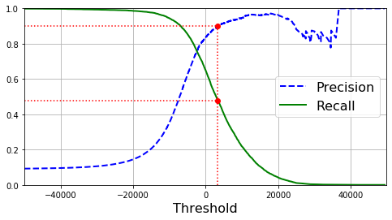

```python
def plot_precision_recall_vs_threshold(precisions, recalls, thresholds):
    plt.plot(thresholds, precisions[:-1], "b--", label="Precision", linewidth=2)
    plt.plot(thresholds, recalls[:-1], "g-", label="Recall", linewidth=2)
    plt.legend(loc="center right", fontsize=16) # Not shown in the book
    plt.xlabel("Threshold", fontsize=16)        # Not shown
    plt.grid(True)                              # Not shown
    plt.axis([-50000, 50000, 0, 1])             # Not shown

plt.figure(figsize=(8, 4))
plot_precision_recall_vs_threshold(precisions, recalls, thresholds)
plt.plot([3370, 3370], [0., 0.9], "r:")         #3370 and 0.479 is threshold and recall calucate from above
plt.plot([-50000, 3370], [0.9, 0.9], "r:")
plt.plot([-50000, 3370], [0.479, 0.479], "r:")
plt.plot([3370], [0.9], "ro")
plt.plot([3370], [0.479], "ro")
plt.show()
```

```python
# make prediction for threshold 3370
y_train_pred_90 = (y_scores >= threshold_90_precision)
#see precision and recall for threshold 3370 (90% precision)
precision_score(y_train_5, y_train_pred_90),recall_score(y_train_5, y_train_pred_90)
```

```
(0.9000345901072293, 0.4799852425751706)
```

#### 4.ROC Curve

The receiver operating characteristic (ROC) curve is sensitivity(recall) versus 1 – specificity.  
plots the true positive rate (another name for recall) against the false positive rate (FPR).(1 – the true negative rate (specitivity))

```python
from sklearn.metrics import roc_curve

fpr, tpr, thresholds = roc_curve(y_train_5, y_scores)
```

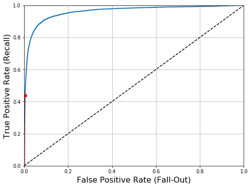

```python
def plot_roc_curve(fpr, tpr, label=None):
    plt.plot(fpr, tpr, linewidth=2, label=label)
    plt.plot([0, 1], [0, 1], 'k--') # dashed diagonal
    plt.axis([0, 1, 0, 1])                                    # Not shown in the book
    plt.xlabel('False Positive Rate (Fall-Out)', fontsize=16) # Not shown
    plt.ylabel('True Positive Rate (Recall)', fontsize=16)    # Not shown
    plt.grid(True)                                            # Not shown

plt.figure(figsize=(8, 6))                         # Not shown
plot_roc_curve(fpr, tpr)
plt.plot([4.837e-3, 4.837e-3], [0., 0.4368], "r:") # Not shown
plt.plot([0.0, 4.837e-3], [0.4368, 0.4368], "r:")  # Not shown
plt.plot([4.837e-3], [0.4368], "ro")               # Not shown                      # Not shown
plt.show()
```

```python
#Calculate AUC(area under the curve)
from sklearn.metrics import roc_auc_score
roc_auc_score(y_train_5,y_scores)
```

```
0.9604938554008616
```

```python
#lets try randomforest classifier
from sklearn.ensemble import RandomForestClassifier
forrest_clf = RandomForestClassifier()
#get predict
y_probas_forrest = cross_val_predict(forrest_clf,X_train,y_train_5,cv = 3,
                                    method='predict_proba')
#evaluate
y_scores_forrest= y_probas_forrest[:,1] # first column is prob of  predict negative , second column is prob of predict positive
roc_auc_score(y_train_5,y_scores_forrest)
```

```
0.9983320617225191
```

### Multiclass Classification

Algorithm when compare to assign class  
OvR = One versus the rest means pick the best output score from all class  
OvO = Iteratively compare one class with another one class for all then pick the last standing  
OvR vs OvO  
Some algorithms (such as Support Vector Machine classifiers) scale poorly with the size of the training set. For these algorithms OvO is preferred because it is faster to train many classifiers on small training sets than to train few classifiers on large training sets. For most binary classification algorithms, however, OvR is preferred.

```python
X_train
```

```
array([[0., 0., 0., ..., 0., 0., 0.],
       [0., 0., 0., ..., 0., 0., 0.],
       [0., 0., 0., ..., 0., 0., 0.],
       ...,
       [0., 0., 0., ..., 0., 0., 0.],
       [0., 0., 0., ..., 0., 0., 0.],
       [0., 0., 0., ..., 0., 0., 0.]])
```

```python
# forced Sklearn to use OvR or OvO with OneVsOneClassifier or OneVsRestClassifier classes.
from sklearn.multiclass import OneVsRestClassifier
from sklearn.svm import SVC

ovr_clf = OneVsRestClassifier(SVC(gamma="auto", random_state=42))
ovr_clf.fit(X_train[:1000], y_train[:1000])
ovr_clf.predict([some_digit])
```

[output not shown]

```python
# number of estimater
len(ovr_clf.estimators_)
```

```
10
```

### Error Analysis

we will assume that you have found a promising model and you want to find ways to improve it. One way to do this is to analyze the types of errors it makes.

```python
y_train_pred = cross_val_predict(sgd_clf, X_train[:1000], y_train[:1000], cv=3)
conf_mx = confusion_matrix(y_train[:1000], y_train_pred[:1000]) # all data take to long so just use slide of data
conf_mx
```

```
array([[ 86,   0,   3,   0,   0,   7,   0,   0,   1,   0],
       [  0, 105,   3,   0,   0,   5,   0,   1,   2,   0],
       [  1,   6,  77,   2,   2,   2,   1,   1,   4,   3],
       [  0,   0,   6,  76,   0,   6,   1,   2,   0,   2],
       [  0,   0,   1,   1,  86,   3,   1,   0,   4,   9],
       [  0,   1,   2,   3,   3,  65,   3,   1,  11,   3],
       [  1,   1,   1,   0,   1,   4,  83,   0,   2,   1],
       [  3,   1,   2,   0,   3,   0,   0, 102,   1,   5],
       [  0,   3,   1,   1,   1,   8,   2,   3,  64,   4],
       [  1,   0,   1,   0,   3,   5,   0,  13,   3,  74]], dtype=int64)
```

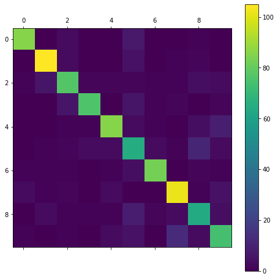

```python
def plot_confusion_matrix(matrix):
    """If you prefer color and a colorbar"""
    fig = plt.figure(figsize=(8,8))
    ax = fig.add_subplot(111)
    cax = ax.matshow(matrix)
    fig.colorbar(cax)

plot_confusion_matrix(conf_mx)
```

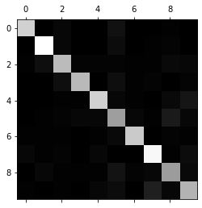

```python
plt.matshow(conf_mx, cmap=plt.cm.gray)
plt.show()
```

divide each value in the confusion matrix by the number of images in the corresponding class so that you can compare error rates instead of absolute numbers of errors

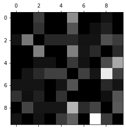

```python
row_sums = conf_mx.sum(axis=1, keepdims=True)
norm_conf_mx = conf_mx / row_sums
#plot
np.fill_diagonal(norm_conf_mx, 0)
plt.matshow(norm_conf_mx, cmap=plt.cm.gray)
plt.show()
```

### Multilabel Classification

In some cases you may want your classifier to output multiple classes for each instance. Consider a face-recognition classifier: what should it do if it recognizes several people in the same picture?  
Say the classifier has been trained to recognize three faces, Alice, Bob, and Charlie. Then when the classifier is shown a picture of Alice and Charlie, it should output [1, 0, 1]

Such a classification system that outputs multiple binary tags is called a multilabel classification system.

```python
# some example
from sklearn.neighbors import KNeighborsClassifier

y_train_large = (y_train >= 7)
y_train_odd = (y_train % 2 == 1)
y_multilabel = np.c_[y_train_large, y_train_odd]

knn_clf = KNeighborsClassifier()
knn_clf.fit(X_train, y_multilabel)
# predict

knn_clf.predict([some_digit])
```

```
array([[False, False]])
```

```python
from sklearn.metrics import f1_score
from sklearn.model_selection import cross_val_predict

y_train_knn_pred = cross_val_predict(knn_clf, X_train, y_multilabel, cv=3)
f1_score(y_multilabel, y_train_knn_pred, average="macro")
```

```
0.976410265560605
```

### Multioutput Classification

generalization of multilabel classification where each label can be multiclass

```python
#example of build a system that removes noise from images
# lets create some noise to the number
noise = np.random.randint(0, 100, (len(X_train), 784))
X_train_mod = X_train + noise

noise = np.random.randint(0, 100, (len(X_test), 784))
X_test_mod = X_test + noise

y_train_mod = X_train
y_test_mod = X_test
```

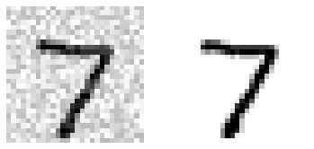

```python
# lets see with and without noise
# some_digit = X_train_mod[0].reshape(28,28) # reshape into 28 x 28
plt.subplot(121) ; plt.imshow(X_test_mod[0].reshape(28,28),cmap = 'binary')
plt.axis('off')
plt.subplot(122); plt.imshow(y_test_mod[0].reshape(28,28),cmap = 'binary')
plt.axis('off')
plt.show(); #image show
```

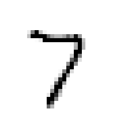

```python
# use knn to remove noise
knn_clf.fit(X_train_mod, y_train_mod)
clean_digit = knn_clf.predict([X_test_mod[some_index]])

# plot
plt.imshow(clean_digit.reshape(28,28),cmap = 'binary')
plt.axis('off')
plt.show();
```

We got pretty good processed digit compare to noise-free photo

# Chapter 4 Training model

## Linear Regression

two very different ways to train it

- Normal equation (close-form) : directly computes the model parameters that best fit the model to the training set
- Gradient Descent (iterative optimization) : gradually tweaks the model parameters to minimize the cost function, eventually converging to the same parameters as the first method

### The Normal equation

Equation to find the best beta for each variable is $\hat{\beta}$ = $(X^T X)^{-1}$ $X^T y$

```python
X = 2 * np.random.rand(100, 1)
y = 4 + 3 * X + np.random.randn(100, 1)
```

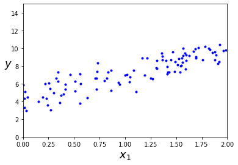

```python
plt.plot(X, y, "b.")
plt.xlabel("$x_1$", fontsize=18)
plt.ylabel("$y$", rotation=0, fontsize=18)
plt.axis([0, 2, 0, 15])
plt.show()
```

```python
X_b = np.c_[np.ones((100, 1)), X]  # add x0 = 1 to each instance
theta_best = np.linalg.inv(X_b.T.dot(X_b)).dot(X_b.T).dot(y)
theta_best
```

```
array([[4.25719205],
       [2.78668098]])
```

#### Computational Complexity

The Normal Equation computes the inverse of $X^T X$, The computational complexity of inverting such a matrix is $O(n^3)$  
Though the prediction are happen very fast regardless of no. rows, If features >1000, It will be slow. So better use Gradient Descent

### Gradient Descent

GD is to tweak parameters iteratively in order to minimize a cost function.

it goes in the direction of the local gradient of the error function with regard to the parameter vector ${\beta}$  
Once the gradient is zero, you have reached a minimum!.

Concretely, you start by filling ${\beta}$ with random values (this is called random initialization). Then improve gradually one step at a time, each step attempting to decrease the cost function (e.g., the MSE), until the algorithm converges to a minimum

**The learning rate** is the size of steps, if its too small, it will go through many iterations to converge. On the other hand, if the learning rate is too high, you end up on possibly even higher up than you were before. This might make the algorithm diverge, with larger and larger values, failing to find a good solution

#### Batch Gradient Descent

Calculate how much the cost function will change if you change θ just a little bit(*partial derivative*), we can calculate all mse for each θ in one go

```python
eta = 0.1  # learning rate
n_iterations = 1000
m = 100

theta = np.random.randn(2,1)  # random initialization

for iteration in range(n_iterations):
    gradients = 2/m * X_b.T.dot(X_b.dot(theta) - y) #take parital delivetive of MSE
    theta = theta - eta * gradients
theta
```

```
array([[4.25719205],
       [2.78668098]])
```

To find a good learning rate, you can use grid search (see Chapter 2). However, you may want to limit the number of iterations so that grid search can eliminate models that take too long to converge.

#### Stochastic Gradient Descent

The main problem with Batch Gradient Descent is the fact that it uses the whole training set to compute the gradients at every step, which makes it very slow when the training set is large.  
At the opposite extreme, *Stochastic Gradient Descent* picks a random instance in the training set at every step and computes the gradients based only on that single instance.  
instead of gently decreasing until it reaches the minimum, the cost function will bounce up and down, decreasing only on average.this can actually help the algorithm jump out of local minima, so Stochastic Gradient Descent has a better chance of finding the global minimum than Batch Gradient Descent does.

```python
#Linear Regression using Stochastic GD with Scikit-Learn
from sklearn.linear_model import SGDRegressor
sgd_reg = SGDRegressor(max_iter=1000, tol=1e-3, penalty=None, eta0=0.1)
sgd_reg.fit(X, y.ravel())
# result
sgd_reg.intercept_, sgd_reg.coef_
```

```
(array([4.2611301]), array([2.80419775]))
```

#### Mini-batch Gradient Descent

Mini-batch GD computes the gradients on small random sets of instances called mini-batches. The main advantage of Mini-batch GD over Stochastic GD is that you can get a performance boost from hardware optimization of matrix operations, especially when using GPUs.

### Polynomial Regression

is a way to fit linear model by add powers of each feature as new features, then train a linear model on this extended features

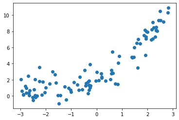

```python
m=100
X = 6* np.random.rand(m,1)-3
y = 2+ (0.5*X**2) + (1.7*X) + np.random.randn(m,1)
plt.scatter(X,y);
```

use Scikit-Learn’s $PolynomialFeatures$ class to transform training data, adding the square of each feature in the training set as a new feature (in this case there is just one feature):

```python
from sklearn.preprocessing import PolynomialFeatures
poly_fea = PolynomialFeatures(degree=2,include_bias=False)
X_poly = poly_fea.fit_transform(X)
X[0], 'It contains the original feature of X plus the square of this feature ',X_poly[0]
```

```
(array([-0.75824981]),
 'It contains the original feature of X plus the square of this feature ',
 array([-0.75824981,  0.57494278]))
```

```python
# now fit linear regression to this extended data
from sklearn.linear_model import LinearRegression
lin_r = LinearRegression()
lin_r.fit(X_poly,y)
lin_r.intercept_, lin_r.coef_
```

```
(array([2.08349514]), array([[1.6508959 , 0.45920454]]))
```

The model estimate intercept = 2, ${\beta}_1$ is 1.65 and ${\beta}_2$ is 0.45  
when in fact the original function was intercept = 2, ${\beta}_1$ is 1.7 and ${\beta}_2$ is 0.5 + Gaussian noise

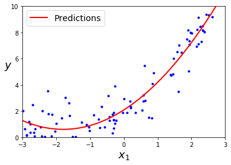

```python
X_new=np.linspace(-3, 3, 100).reshape(100, 1)
X_new_poly = poly_fea.fit_transform(X_new)
y_new = lin_r.predict(X_new_poly)
plt.plot(X, y, "b.")
plt.plot(X_new, y_new, "r-", linewidth=2, label="Predictions")
plt.xlabel("$x_1$", fontsize=18)
plt.ylabel("$y$", rotation=0, fontsize=18)
plt.legend(loc="upper left", fontsize=14)
plt.axis([-3, 3, 0, 10])
plt.show();
```

## Learning Curve

how can you decide how complex your model should be? How can you tell that your model is overfitting or underfitting the data  
If

a model performs well on the training data but generalizes poorly according to the cross-validation metrics, then your model is overfitting. If it performs poorly on both, then it is underfitting. This is one way to tell when a model is too simple or too complex.

Another way to tell is to look at the learning curves: these are plots of the model’s performance on the training set and the validation set as a function of the training set size (or the training iteration). To generate the plots, train the model several times on different sized subsets of the training set.

```python
from sklearn.metrics import mean_squared_error
from sklearn.model_selection import train_test_split

def plot_learning_curves(model, X, y):
    X_train, X_val, y_train, y_val = train_test_split(X, y, test_size=0.2, random_state=10)
    train_errors, val_errors = [], []
    for m in range(1, len(X_train)):
        model.fit(X_train[:m], y_train[:m])
        y_train_predict = model.predict(X_train[:m])
        y_val_predict = model.predict(X_val)
        train_errors.append(mean_squared_error(y_train[:m], y_train_predict))
        val_errors.append(mean_squared_error(y_val, y_val_predict))

    plt.plot(np.sqrt(train_errors), "r-+", linewidth=2, label="train")
    plt.plot(np.sqrt(val_errors), "b-", linewidth=3, label="val")
    plt.legend(loc="upper right", fontsize=14)
    plt.xlabel("Training set size", fontsize=14)
    plt.ylabel("RMSE", fontsize=14)
```

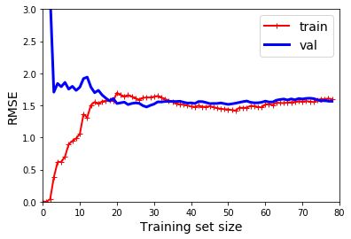

```python
lin_reg = LinearRegression()
plot_learning_curves(lin_reg, X, y)
plt.axis([0, 80, 0, 3])
plt.show()
```

Above is Learning curve of simple linear regression  
These learning curves are typical of a model that’s underfitting. Both curves have reached a plateau; they are close and fairly high.

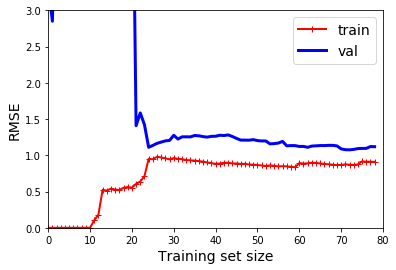

```python
from sklearn.pipeline import Pipeline
polynomia_r = Pipeline([
    ('transfrom_poly',PolynomialFeatures(degree= 10,include_bias=False)),
    ('fit_linear',LinearRegression())
])

plot_learning_curves(polynomia_r,X,y)
plt.axis([0, 80, 0, 3])
plt.show()
```

Learning Curve of 10th polynomial  
The error on the training data is much lower than with the Linear Regression model  
There is a gap between the curves. This means that the model performs significantly better on the training data than on the validation data, which is an overfitting model

##### THE BIAS/VARIANCE TRADE-OFF

model’s **generalization error*** can be expressed as the sum of three very different errors

- *Bias*  
  due to wrong assumptions, such as assuming that the data is linear when it is actually quadratic. and most likely to underfit the training data
- *Variance*  
  due to the model too sensitive to small variations in the training data(too flex, or over complicate) and likely to overfit the data
- *Irreducible error*  
  due to the noisiness of the data itself. The only way to reduce this part of the error is to clean up the data

## Regularized Linear Models

Reduce overfitting of Linear model by constraint it to fewer degrees of freedom(remove some ${\beta}$) or constraining the weights of the mode

### Ridge Regression

use half the square of the $(L^2)$ norm of weight vector $J(θ) = MSE(θ) + α \frac{1}{2}\sum θ_{i}^{2}$  
add α regularization term to cost function to keep the model weights as small as possible.  
The hyperparameter α controls how much to regularize the model. If α = 0, then Ridge Regression is just Linear Regression. If α is very large, then all weights end up very close to zero and the result is a flat line going through the data’s mean.

```python
from sklearn.linear_model import Ridge
ridge_reg= Ridge(alpha=1,solver='cholesky').fit(X,y)
ridge_reg.predict([[1.5]])
```

```
array([[5.84349376]])
```

```python
#Stochastic Gradient Descent
sgd_reg = SGDRegressor(penalty='l2').fit(X,y.ravel()) # ravel() reshape to 1D
sgd_reg.predict([[1.5]])
```

```
array([5.82949108])
```

### Lasso Regression

```python
from sklearn.linear_model import Lasso # or SGDRegressor(penalty="l1") for SGD
lasso_reg = Lasso(alpha=0.1).fit(X,y)
lasso_reg.predict([[1.5]])
```

```
array([5.80065181])
```

### Elastic Net

middle ground between Ridge and Lasso where you can control weight when r = 1, it is equivalent to Lasso.

```python
from sklearn.linear_model import ElasticNet
elas_r = ElasticNet(l1_ratio=0.5, alpha=0.1).fit(X,y)
elas_r.predict([[1.5]])
```

```
array([5.78835009])
```

### Summary

In general you should avoid plain Linear Regression. Ridge is a good default, but if you suspect that only a few features are useful, you should prefer Lasso or Elastic Net because they tend to reduce the useless features’ weights down to zero, as we have discussed. In general, Elastic Net is preferred over Lasso because Lasso may behave erratically when the number of features is greater than the number of training instances or when several features are strongly correlated.

## Logistic Regression

estimate the probability that an instance belongs to a particular class  
Just like a Linear Regression model, a Logistic Regression model computes a weighted sum of the input features but instead of outputting the result directly like the Linear Regression model does, it outputs the *logistic(sigmoid function value betwwen 0 and 1)* of the result.  
$\frac{1}{1+exp(-t)}$

```python
from sklearn import indicess
iris = indicess.load_iris()
print(iris.keys())
X = iris["data"][:, 3:]
y = (iris["target"] == 2).astype(np.int) # 1 if Iris virginica, else 0
```

```
dict_keys(['data', 'target', 'target_names', 'DESCR', 'feature_names', 'filename'])
```

```python
#train with logistic regression
from sklearn.linear_model import LogisticRegression
log_reg = LogisticRegression(solver="lbfgs", random_state=42)
log_reg.fit(X, y)
```

```
LogisticRegression(C=1.0, class_weight=None, dual=False, fit_intercept=True,
                   intercept_scaling=1, l1_ratio=None, max_iter=100,
                   multi_class='auto', n_jobs=None, penalty='l2',
                   random_state=42, solver='lbfgs', tol=0.0001, verbose=0,
                   warm_start=False)
```

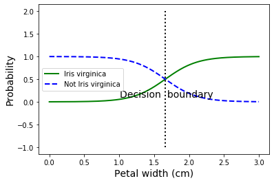

```python
X_new = np.linspace(0, 3, 1000).reshape(-1, 1)
y_proba = log_reg.predict_proba(X_new)

decision_boundary = X_new[y_proba[:, 1] >= 0.5][0]
plt.plot(X_new, y_proba[:, 1], "g-", linewidth=2, label="Iris virginica")
plt.plot(X_new, y_proba[:, 0], "b--", linewidth=2, label="Not Iris virginica")
plt.legend(loc="center left", fontsize=10)
plt.xlabel("Petal width (cm)", fontsize=14)
plt.ylabel("Probability", fontsize=14)
plt.text(decision_boundary+0.02, 0.1, "Decision  boundary", fontsize=14, color="k", ha="center")
plt.plot([decision_boundary, decision_boundary], [-1, 2], "k:", linewidth=2)
plt.show()
```

there is a decision boundary at around 1.6 cm where both probabilities are equal to 50%

### Softmax Regression (Multinomial Logistic Regression)

The Logistic Regression model can be generalized to support multiple classes directly  
Softmax Regression model first computes a score s (x) for each class k, then estimates the probability of each class by applying the softmax function (also called the normalized exponential) to the scores

```python
# set the multi_class hyperparameter to "multinomial" to switch it to Softmax Regression
X = iris["data"][:, (2, 3)] # petal length, petal width
y = iris["target"]
softmax_reg = LogisticRegression(multi_class="multinomial",solver="lbfgs", C=10)
softmax_reg.fit(X, y)
softmax_reg.predict_proba([[5, 2]])
```

```
array([[6.38014896e-07, 5.74929995e-02, 9.42506362e-01]])
```

# 5. Support Vector Machine

SVMs are particularly well suited for classification of complex small- or mediumsized indicess.  
However, it is capable of performing linear or nonlinear classification, regression, and even outlier detection

**Soft Margin Classification** will generalize better than hard margin and less sensitive to outliers.  
The objective is to find a good balance between keeping the street as large as possible and limiting the margin violations  
Using $C$ hyper parameter to limit number of observations that can cross the boundary

```python
X = iris['data']
y = iris['target']
```

Different kernel of SVM

- 'linear' : work with linear indices
- 'polynomial' + degree : add degree to separate nonlinear indices. The higher degree the more complex
- 'rbf' (Gussian) +gamma : similar to add new features by computed how much each instance a particular Gussian landmark (select location from random instance). the higher gamma the more complex(makes the bell-shaped curve narrower)

**Summary** : try 'linear' first (fast with a lot data) but if data is not too big try 'rbf' then for the rest if have spare time

```python
from sklearn.svm import SVC
from sklearn.pipeline import Pipeline
from sklearn.preprocessing import StandardScaler
from sklearn.model_selection import GridSearchCV
std_sca = StandardScaler()
X1 = std_sca.fit_transform(X)
```

```python
# try 'linear','rbf','poly' on iris
param = [{
    'kernel':['linear','rbf','poly']
}]
svc = SVC()
grid_svc = GridSearchCV(svc,param_grid=param,cv=3)
grid_svc.fit(X1,y)
pd.DataFrame({
    'kernel':grid_svc.cv_results_['params'],
    'score' :grid_svc.cv_results_['mean_test_score']
})
```

|  | kernel | score |
| --- | --- | --- |
| 0 | {'kernel': 'linear'} | 0.980000 |
| 1 | {'kernel': 'rbf'} | 0.966667 |
| 2 | {'kernel': 'poly'} | 0.933333 |

# Decision Tree

In fact, they don’t require feature scaling or centering at all

CART Training Algorithm  
The algorithm works by first splitting the training set into two subsets using a single feature $k$ and a threshold $t_k$  
then search for a pair of $(k,t_k)$ that produces the purest subsets and split data in two and split recursively.

## Gini Impurity or Entropy?

Gini is zero pure meaning this leaf only contain 1 class, the we average all Gini.  
entropy is is zero pure meaning this leaf only contain 1 class  
different is , Gini impurity tends to isolate the most frequent class in its own branch of the tree, while entropy tends to produce slightly more balanced trees

## Regularization Hyperparameters

Decision tree is a *nonparametric model* not because it does not have any parameters (it often has a lot) but because the number of parameters is not determined prior to training, so the model structure is free to stick closely to the data. Hence easy to overfit.

To avoid overfittiing, need to restrict the Decision Tree’s freedom by regularization hyperparameters.  
Increasing min* hyperparameters or reducing max* hyperparameters will regularize the model

## Limitation

Decision tree split with straight line result in rectangle decision boundaries. If indices rotate, Decision tree with have hard time generalize. One way to fix is using PCA for better orientation of the data  
It also very sensitive to outliers

# Ensemble and Random Forrest

the most popular Ensemble methods, including bagging, boosting, and stacking.  
Ensemble methods work best when the predictors are as independent from one another as possible. One way to get diverse classifiers is to train them using very different algorithms. This increases the chance that they will make very different types of errors, improving the ensemble’s accuracy

```python
#import data
from sklearn.model_selection import train_test_split
from sklearn.indicess import make_moons

X, y = make_moons(n_samples=500, noise=0.30, random_state=42)
X_train, X_test, y_train, y_test = train_test_split(X, y, random_state=42)
```

```python
# try ensemble with Logistic ,Random forrest and SVC
from sklearn.ensemble import VotingClassifier
from sklearn.ensemble import RandomForestClassifier

rnd = RandomForestClassifier()
svc = SVC()
logis = LogisticRegression()

vote = VotingClassifier(estimators= [('random',rnd),
                                    ('svc',svc),
                                    ('log',logis)],
                       voting='hard')
# vote.fit(X_train,y_train)
```

```python
#evaluatation
from sklearn.metrics import accuracy_score
for clf in (rnd, svc, logis, vote):
    clf.fit(X_train, y_train)
    y_pred = clf.predict(X_test)
    print(clf.__class__.__name__, accuracy_score(y_test, y_pred))
```

```
RandomForestClassifier 0.888
SVC 0.896
LogisticRegression 0.864
VotingClassifier 0.904
```

Voting slightly better than others  
**Voting approach**

- Hard voting : result with the majority vote class of all algorithms
- Soft voting : Use predict_proba instead, and average probability of each class then pick the class with highest probability. This often better than hard voting because it gives more weight to highly confident vote

## Bagging and Pasting

When use same training algorithm for every predictor on random subsets of training data set with replacement called *Bagging* and without replacement called *Pasting*

```python
from sklearn.ensemble import BaggingClassifier
from sklearn.tree import DecisionTreeClassifier
bag_clf = BaggingClassifier(DecisionTreeClassifier(),
                            n_estimators=500, # 500 trees
                            max_samples=100, # each train 100 observations randomly
                            bootstrap=True,# set bootstrap = False for Pasting instead
                            oob_score=True, # use out of bag(obervation that not random select for training) for validation
                            n_jobs=-1)  #set n_job = -1 to use all cpu cores
bag_clf.fit(X_train,y_train).score(X_train,y_train) ,bag_clf.oob_score_
```

```
(0.9386666666666666, 0.9226666666666666)
```

## Random Forrest

Decision tree the that generally randomly select all training data to train with randomly selected features. The results in greater tree diversity, which (again) trades a higher bias for a lower variance, generally yielding an overall better model.

```python
rnd_clf = RandomForestClassifier(n_estimators=500,n_jobs=-1,max_leaf_nodes=16)
rnd_clf.fit(X_train,y_train).score(X_train,y_train)
```

```
0.952
```

### Feature Importance

Scikit-Learn measures a feature’s importance by looking at how much the tree nodes that use that feature reduce impurity on average (across all trees in the forest). More precisely, it is a weighted average.

```python
X,y = iris['data'] , iris['target']
rnd_iris = RandomForestClassifier(n_estimators=500,n_jobs=-1,max_leaf_nodes=16)
rnd_iris.fit(X,y)
[i for i in zip(iris['feature_names'],rnd_iris.feature_importances_)] , rnd_iris.feature_importances_.sum()
```

```
([('sepal length (cm)', 0.08705530341982062),
  ('sepal width (cm)', 0.021201629302896482),
  ('petal length (cm)', 0.4250977538734858),
  ('petal width (cm)', 0.46664531340379717)],
 1.0)
```

## Boosting

train predictors sequentially, each trying to correct its predecessor.  
It pay a bit more attention to the training instances that the predecessor underfitted. This results in new predictors focusing more and more on the hard cases.

### AdaBoost

*tweaking the instance weights at every iteration*  
It increases the relative weight of misclassified training instances. Then it trains a second classifier, using the updated weights, and again makes predictions on the training set, updates the instance weights, and so on

```python
from sklearn.ensemble import AdaBoostClassifier
ada_clf = AdaBoostClassifier(DecisionTreeClassifier(max_depth=1), #each tree only 1 depth
                             n_estimators=200,learning_rate=0.5)
ada_clf.fit(X,y)
ada_clf.score(X,y)
```

```
0.9266666666666666
```

### Gradient Boosting

*fit the new predictor to the residual errors(ytrue-ypred) made by the previous predictor*

```python
from sklearn.ensemble import GradientBoostingClassifier
gra_clf = GradientBoostingClassifier(n_estimators=100,max_depth=1)
gra_clf.fit(X,y).score(X,y)
```

```
0.9866666666666667
```

#### staged_predict() to find the optimal number of trees

It returns an iterator over the predictions made by the ensemble at each stage of training  
Then we can measure the validation error at each stage of training to find the optimal number of trees, and finally trains another GBRT ensemble using the optimal number of trees:

```python
from sklearn.ensemble import GradientBoostingRegressor
from sklearn.metrics import mean_squared_error
X_train, X_val, y_train, y_val = train_test_split(X, y, random_state=49)

gbrt = GradientBoostingRegressor(max_depth=2, n_estimators=120, random_state=42)
gbrt.fit(X_train, y_train)

errors = [mean_squared_error(y_val, y_pred)
          for y_pred in gbrt.staged_predict(X_val)]
# choose number of tree(estimator) that minimize mse on validation set
bst_n_estimators = np.argmin(errors) +1

gbrt_best = GradientBoostingRegressor(max_depth=2, n_estimators=bst_n_estimators, random_state=42)
gbrt_best.fit(X_train, y_train).score(X_train, y_train)
```

```
0.9729099137367679
```

#### XGboost

a more regularized model formalization to control over-fitting or Gradient Boost, which gives it better performance

```python
import xgboost

xgb_reg = xgboost.XGBRegressor()
xgb_reg.fit(X_train,y_train)
y_pred = xgb_reg.predict(X_val)

val_error = mean_squared_error(y_val, y_pred)
print("Validation MSE:", val_error)
```

```
[22:50:53] WARNING: src/objective/regression_obj.cu:152: reg:linear is now deprecated in favor of reg:squarederror.
Validation MSE: 0.06416875852771033
```

## Stacking

Instead of using hard voting, we train a model to perform the aggregation of predictors.  
with $brew$

# 8. Dimensionality Reduction

Benefit : Speeding up training and visualization

## Curse of Dimensionality

The higher dimension the more plenty of space it has, Hence high-dimensional indicess are at risk of being very sparse meaning each instance likely be far from others. As well as new instance and training instance.  
In short, the more dimensions the training set has, the greater the risk of overfitting it.

## Approaches for Dimensionality Reduction

### Projection

In most real-world problems, training instances are not spread out uniformly across all dimensions. Many features are almost constant, while others are highly correlated (as in MNIST). As a result, all training instances lie within (or close to) a much lower-dimensional subspace of the high-dimensional space. (eg data in 3D may dense in a plane like 2D)

### Manifold Learning

Reduce non-linear indices dimension in to 2D snapshot that really depend on data

## PCA

it identifies the hyperplane that lies closest to the data, and then it projects the data onto it.  
We choosing the hyperplane by choosing the first axis that preserve the most variance and then another orthogonal axis that preserve most variance and so on so forth. (it is the axis that minimizes the mean squared distance between the original indices and its projection onto that axis.)

These axis are called *Principal Component*  
Using SVD (matrix factorization) can decompose matrix in to $UEV^T$ where V contain all unit vector of principal component

```python
# create sample 3D indicess
np.random.seed(4)
m = 60
w1, w2 = 0.1, 0.3
noise = 0.1
angles = np.random.rand(m) * 3 * np.pi / 2 - 0.5
X = np.empty((m, 3))
X[:, 0] = np.cos(angles) + np.sin(angles)/2 + noise * np.random.randn(m) / 2
X[:, 1] = np.sin(angles) * 0.7 + noise * np.random.randn(m) / 2
X[:, 2] = X[:, 0] * w1 + X[:, 1] * w2 + noise * np.random.randn(m)
```

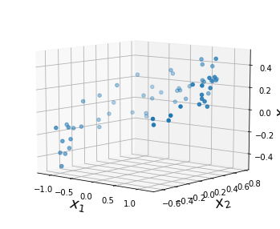

```python
# plot
fig = plt.figure(figsize=(6, 5))
ax = fig.add_subplot(111, projection='3d')
ax.scatter(X[:, 0], X[:, 1], X[:, 2])
ax.view_init(10, -50)
ax.set_xlabel("$x_1$", fontsize=18)
ax.set_ylabel("$x_2$", fontsize=18)
ax.set_zlabel("$x_3$", fontsize=18)

plt.show();
```

```python
#using numpy to get two first principal components
X_centered = X- X.mean(axis = 0)
U, E, Vt = np.linalg.svd(X_centered)
princ1 = Vt.T[:,0]
princ2 = Vt.T[:,1]
princ2
```

```
array([-0.34027485,  0.90119108,  0.2684542 ])
```

```python
# using sklearn (auto center the data)
from sklearn.decomposition import PCA
pca = PCA(n_components=2) # down to 2D
X2d = pca.fit_transform(X)
X2d[:5]
```

```
array([[ 1.26203346,  0.42067648],
       [-0.08001485, -0.35272239],
       [ 1.17545763,  0.36085729],
       [ 0.89305601, -0.30862856],
       [ 0.73016287, -0.25404049]])
```

```python
# get explained variance from 1st and 2nd PC
pca.explained_variance_ratio_ # 84% and 14%
```

```
array([0.84248607, 0.14631839])
```

#### Choosing the right number of Dimensions

2-3 D for Visualization  
But for reduce dimension get dimensions that add up to a sufficiently large portion of the variance (e.g., 95%).  
Or plot elbow curve for cumsum variance explain (see Python for DS notebook)

```python
#import data set
from sklearn.indicess import fetch_openml
mnist = fetch_openml('mnist_784', version =1)
mnist.keys()
X , y = mnist['data'], mnist['target']
X.shape, y.shape
```

```
((70000, 784), (70000,))
```

```python
pca = PCA(n_components=.95) # get PC the sum variance more that 99.5%
pca.fit(X)
len(pca.explained_variance_ratio_) # from 784 result in 154 PC
```

```
154
```

```python
# get PC
X_pca = pca.transform(X)
# decompress PC to reconstructed data (will not be the same with original cause loss 5% of data)
X_reconstructed = pca.inverse_transform(X_pca)
```

#### Incremental PCA (mini batch feed data into PCA)

split the training set into mini-batches and feed an IPCA algorithm one mini-batch at a time. So not require the whole training set to fit in memory

```python
# with partial fit
from sklearn.decomposition import IncrementalPCA
nbatch = 100
ipca = IncrementalPCA(n_components=154)
for X_batch in np.array_split(X,nbatch):
    ipca.partial_fit(X_batch)

X_ipca = ipca.transform(X)
```

### Kernel PCA

perform complex nonlinear projections for dimensionality reduction  
It is often good at preserving clusters of instances after projection, or sometimes even unrolling indicess that lie close to a twisted manifold

```python
from sklearn.decomposition import KernelPCA
# kpca = KernelPCA(n_components=.95,kernel = 'rbf',gamma = 0.4).fit(X)
```

## LLE (Locally Linear Embedding)

*non linear dimensionality reduction* that rely on Manifold.  
first measuring how each training instance linearly relates to its closest neighbors (c.n.), and then looking for a low-dimensional representation of the training set where these local relationships are best preserved

## Other Dimension reduction technique

- *Random Projections*  
  projects the data to a lower-dimensional space using a random linear projection.
- *Multidimensional Scaling (MDS)*  
  Reduces dimensionality while trying to preserve the distances between the instances.
- *Isomap*  
  Creates a graph by connecting each instance to its nearest neighbors, then reduces dimensionality while trying to preserve the geodesic distances between the instances.
- *t-Distributed Stochastic Neighbor Embedding (t-SNE)*  
  Reduces dimensionality while trying to keep similar instances close and dissimilar instances apart. It is mostly used for visualization, in particular to visualize clusters of instances in highdimensional space (e.g., to visualize the MNIST images in 2D).
- *Linear Discriminant Analysis (LDA)*  
  Is a classification algorithm, but during training it learns the most discriminative axes between the classes, and these axes can then be used to define a hyperplane onto which to project the data. The benefit of this approach is that the projection will keep classes as far apart as possible, so LDA is a good technique to reduce dimensionality before running another classification algorithm such as an SVM classifier.

# 9. Unsupervised Learning Techniques

- Clustering

  The goal is to group similar instances together into clusters. Clustering is a great tool for data analysis, customer segmentation, recommender systems, search engines, image segmentation, semi-supervised learning, dimensionality reduction, and more.
- Anomaly detection

  The objective is to learn what “normal” data looks like, and then use that to detect abnormal instances, such as defective items on a production line or a new trend in a time series.
- Density estimation

  This is the task of estimating the probability density function (PDF) of the random process that generated the indices. Density estimation is commonly used for anomaly detection: instances located in very low-density regions are likely to be anomalies. It is also useful for data analysis and visualization.

### Clustering

Some algorithms look for instances centered around a particular point, called a centroid. Others look for continuous regions of densely packed instances: these clusters can take on any shape. Some algorithms are hierarchical, looking for clusters of clusters. And the list goes on.

### K-Means

```python
from sklearn.cluster import KMeans
from sklearn.indicess import make_blobs
#import indices
X,y = make_blobs(n_samples=200,random_state=42,centers=5)
kmean= KMeans(n_clusters= 5, # number of cluster
             #init= np.array([[-3, 3], [-3, 2], [-3, 1], [-1, 2], [0, 2]]), # assign start centroids
             n_init=10) # randomly run 10 times (not use when init is here)
kmean.fit(X,y)
y_pred = kmean.predict(X)
```

```python
# evaluation with inertia (mean squared distance from each instance to its closest centroid)
kmean.inertia_
```

```
350.5751653913808
```

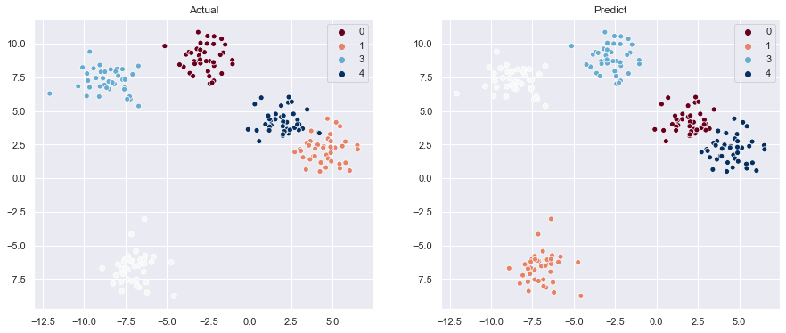

```python
f = plt.figure(figsize=(15, 6))
gs = f.add_gridspec(1, 2)

ax = f.add_subplot(gs[0, 0])
plt.title('Actual')
sns.scatterplot(X[:,0],X[:,1],hue=y,palette="RdBu")

ax = f.add_subplot(gs[0, 1])
plt.title('Predict')
sns.scatterplot(X[:,0],X[:,1],hue=y_pred,palette="RdBu");
```

```python
from sklearn.metrics import silhouette_score
silhouette_score(X, kmean.labels_)
```

```
0.6722663367932022
```

```python
#Minibatch Kmean make it possible to deal with large indices
from sklearn.cluster import MiniBatchKMeans
minibatch_kmeans = MiniBatchKMeans(n_clusters=5)
minibatch_kmeans.fit(X)
```

#### Limits of K-Means

Despite its many merits, most notably being fast and scalable, K-Means is not perfect. As we saw, it is necessary to run the algorithm several times to avoid suboptimal solutions, plus you need to specify the number of clusters, which can be quite a hassle. Moreover, K-Means does not behave very well when the clusters have varying sizes, different densities, or nonspherical shapes.

#### Using Kmean as preprocessing step

```python
from sklearn.indicess import load_digits
X_digits, y_digits = load_digits(return_X_y=True)
X_train, X_test, y_train, y_test = train_test_split(X_digits, y_digits)
# fit logistic Regression
from sklearn.linear_model import LogisticRegression
log_reg = LogisticRegression(max_iter=2000)
log_reg.fit(X_train, y_train)
log_reg.score(X_test, y_test)
```

```
0.96
```

```python
# Kmean and then fit Logistic regression
from sklearn.pipeline import Pipeline
pipe = Pipeline([('kmean1',KMeans(n_clusters=50)),
                 ('logsitic',LogisticRegression(max_iter=10000))])
pipe.fit(X_train, y_train)
pipe.score(X_test, y_test)
```

```
0.9622222222222222
```

model with Kmean Score a little better with k=50 but we can do gridsearch to find the best K

```python
from sklearn.model_selection import GridSearchCV
pipe = Pipeline([('kmean',KMeans()),
                 ('logsitic',LogisticRegression(max_iter=10000))])
param = {'kmean__n_clusters': range(97, 101)} # estmator + __ +param name
grid = GridSearchCV(pipe,param_grid=param,cv = 3,verbose=2)
grid.fit(X_train,y_train)
grid.score(X_test, y_test)
```

```
Fitting 3 folds for each of 4 candidates, totalling 12 fits
[CV] kmean__n_clusters=97 ............................................
```

```
[Parallel(n_jobs=1)]: Using backend SequentialBackend with 1 concurrent workers.
```

```
[CV] ............................. kmean__n_clusters=97, total=   2.1s
[CV] kmean__n_clusters=97 ............................................
```

[output not shown]

[output not shown]

```
[Parallel(n_jobs=1)]: Done  12 out of  12 | elapsed:   50.7s finished
```

```
0.9733333333333334
```

```python
grid.best_params_
```

```
{'kmean__n_clusters': 99}
```

With k = 99 clusters, we get a significant accuracy boost, reaching 97.33%

## Using Clustering for Semi-Supervised Learning

Another use case for clustering is in semi-supervised learning, when we have plenty of unlabeled instances and very few labeled instances.

```python
# let assume and train only 50 images
n_labeled = 50
log_reg = LogisticRegression(multi_class="ovr", solver="lbfgs", random_state=42)
log_reg.fit(X_train[:n_labeled], y_train[:n_labeled])
log_reg.score(X_test, y_test)
```

```
0.7422222222222222
```

```python
k=20
kmean = KMeans(n_clusters=k)
X_digits_dist = kmean.fit_transform(X_train)
representative_digit_idx = np.argmin(X_digits_dist, axis=0)
X_representative_digits = X_train[representative_digit_idx]
```

Now let's plot these representative images and label them manually:

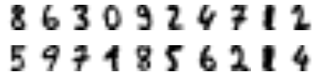

```python
plt.figure(figsize=(8, 2))
for index, X_representative_digit in enumerate(X_representative_digits):
    plt.subplot(k // 10, 10, index + 1)
    plt.imshow(X_representative_digit.reshape(8, 8), cmap="binary", interpolation="bilinear")
    plt.axis('off')
plt.show()
```

```python
y_representative_digits = np.array([
    8, 6, 3, 0, 9, 2, 4, 7, 1, 2,
    5, 9, 7, 1, 8, 5, 6, 2, 1, 4])
```

```python
log_reg = LogisticRegression(multi_class="ovr", solver="lbfgs", max_iter=5000, random_state=42)
log_reg.fit(X_representative_digits, y_representative_digits)
log_reg.score(X_test, y_test)
```

```
0.84
```

Even only 20 represent image we have better performance than 50 first image. If we increase represent image performance would be higher

What if we propagated(extend) label of this 20 to every image in its cluster

```python
y_train_propagated = np.empty(len(X_train), dtype=np.int32)
for i in range(k):
    y_train_propagated[kmean.labels_==i] = y_representative_digits[i]
```

```python
log_reg = LogisticRegression(multi_class="ovr", solver="lbfgs", max_iter=5000, random_state=42)
log_reg.fit(X_train, y_train_propagated)
log_reg.score(X_test, y_test)
```

```
0.9044444444444445
```

Some instance near boundaries will likely be mislabel

Let’s see what happens if we only propagate the labels to the 20% of the instances that are closest to the centroids:

```python
percentile_closest = 20

X_cluster_dist = X_digits_dist[np.arange(len(X_train)), kmean.labels_]
for i in range(k):
    in_cluster = (kmean.labels_ == i)
    cluster_dist = X_cluster_dist[in_cluster]
    cutoff_distance = np.percentile(cluster_dist, percentile_closest)
    above_cutoff = (X_cluster_dist > cutoff_distance)
    X_cluster_dist[in_cluster & above_cutoff] = -1

partially_propagated = (X_cluster_dist != -1)
X_train_partially_propagated = X_train[partially_propagated]
y_train_partially_propagated = y_train_propagated[partially_propagated]
```

```python
log_reg = LogisticRegression(multi_class="ovr", solver="lbfgs", max_iter=5000)
log_reg.fit(X_train_partially_propagated, y_train_partially_propagated)
log_reg.score(X_test, y_test)
```

```
0.8888888888888888
```

```python
np.mean(y_train_partially_propagated == y_train[partially_propagated])
```

```
0.9856115107913669
```

### DBSCAN

DBSCAN defines cluster as continuous regions of high density. *This algorithm works well if all the clusters are dense enough and if they are well separated by lowdensity regions.*

For each instance, the algorithm counts how many instances are located within a small distance $ε$ (epsilon) from it. This region is called the instance’s $ε$-neighborhood.

If an instance has at least min_samples instances in its ε-neighborhood (including itself), then it is considered a core instance. In other words, core instances are those that are located in dense regions.

All instances in the neighborhood of a core instance belong to the same cluster. This neighborhood may include other core instances; therefore, a long sequence of neighboring core instances forms a single cluster.

Any instance that is not a core instance and does not have one in its neighborhood is considered an anomaly.

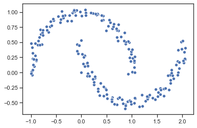

```python
from sklearn.cluster import DBSCAN
from sklearn.indicess import make_moons

X,y = make_moons(200,noise=0.05)
sns.scatterplot(X[:,0],X[:,1]);
```

```python
dbs = DBSCAN(eps=0.3,min_samples=4)
dbs.fit(X)
dbs.labels_ #The labels of all the instances are now available in the labels_ instance variable
# some instance that labels = -1 means DBS thinks it is outliers
```

```
array([0, 0, 1, 1, 0, 0, 1, 0, 1, 1, 0, 1, 0, 1, 0, 0, 1, 0, 1, 0, 0, 0,
       0, 0, 0, 1, 1, 0, 0, 0, 0, 1, 1, 1, 1, 1, 1, 1, 0, 0, 1, 1, 1, 1,
       0, 1, 1, 1, 0, 1, 1, 0, 1, 0, 1, 0, 1, 1, 1, 1, 0, 1, 1, 0, 0, 0,
       1, 1, 0, 1, 0, 1, 1, 1, 0, 1, 0, 1, 0, 0, 0, 1, 1, 0, 1, 0, 0, 0,
       0, 1, 0, 0, 1, 0, 1, 1, 1, 0, 1, 1, 0, 1, 0, 0, 1, 0, 0, 1, 1, 0,
       0, 0, 1, 0, 0, 0, 1, 0, 0, 1, 0, 0, 1, 1, 1, 0, 0, 1, 0, 0, 0, 0,
       0, 1, 0, 1, 0, 1, 0, 0, 1, 1, 1, 1, 1, 1, 0, 1, 0, 0, 1, 1, 1, 0,
       0, 0, 1, 0, 1, 1, 1, 0, 0, 1, 0, 1, 1, 0, 0, 1, 1, 1, 1, 1, 1, 1,
       1, 0, 0, 0, 0, 0, 1, 0, 1, 0, 0, 0, 0, 1, 0, 0, 1, 1, 1, 0, 0, 0,
       1, 1], dtype=int64)
```

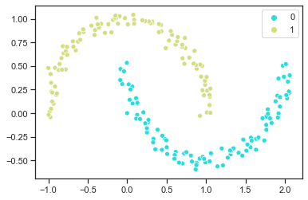

```python
sns.scatterplot(X[:,0],X[:,1],hue=dbs.labels_,palette='rainbow');
```

Now, given a few new instances, we can predict which cluster they most likely belong to and even estimate a probability for each cluster using KNeighborsClassifier given dbscan compenent

```python
from sklearn.neighbors import KNeighborsClassifier
knn = KNeighborsClassifier(n_neighbors=30)
knn.fit(dbs.components_ # core components
        , dbs.labels_[dbs.core_sample_indices_]) #label of core components

# new array
X_new = np.array([[-0.5, 0], [0, 0.5], [1, -0.1], [2, 1]])
knn.predict(X_new)
```

```
array([1, 0, 0, 0], dtype=int64)
```

```python
knn.predict_proba(X_new) # return probability to decide which cluster
```

```
array([[0.43333333, 0.56666667],
       [0.53333333, 0.46666667],
       [0.6       , 0.4       ],
       [0.83333333, 0.16666667]])
```

In short, DBSCAN is a very simple yet powerful algorithm capable of identifying any number of clusters of any shape. It is robust to outliers, and it has just two hyperparameters (eps and min_samples). If the density varies significantly across the clusters, however, it can be impossible for it to capture all the clusters properly. Its computational complexity is roughly O(m log m), making it pretty close to linear with regard to the number of instances, but Scikit-Learn’s implementation can require up to O(m ) memory if eps is large.

### Gaussian Mixtures

GMM can be used for density estimation, clustering, generative (sample new data), and anomaly detection.  
GMM is probabilistic model that assumes that the instances were generated from a mixture of several Gaussian distributions whose parameters are unknown

All the instances generated from a single Gaussian distribution form a cluster that typically looks like an ellipsoid. Each cluster can have a different ellipsoidal shape, size, density, and orientation

```python
from sklearn.mixture import GaussianMixture
gmm = GaussianMixture()
gmm.predict_proba()  # solf clustering (return prob for each cluster)
gmm.score_samples() #generate new sample for same distribution and parameter
```

#### Anomaly Detection Using Gaussian Mixtures

any instance located in a lowdensity region can be considered an anomaly. You must define what density threshold you want to use  
If you notice that you get too many false positives (i.e., perfectly good products that are flagged as defective), you can lower the threshold. Conversely, if you have too many false negatives (i.e., defective products that the system does not flag as defective), you can increase the threshold

```python
densities = gm.score_samples(X)
density_threshold = np.percentile(densities, 4) # set 4% of data is outliers
anomalies = X[densities < density_threshold]
```

#### Bayesian Gaussian Mixture Models

Rather than manually searching for the optimal number of clusters, you can use the BayesianGaussianMixture class, which is capable of giving weights equal (or close) to zero to unnecessary clusters. Set the number of clusters n_components to a value that you have good reason to believe is greater than the optimal number of clusters (this assumes some minimal knowledge about the problem at hand), and the algorithm will eliminate the unnecessary clusters automatically.

```python
from sklearn.mixture import BayesianGaussianMixture
bgm = BayesianGaussianMixture(n_components=10, n_init=10, random_state=42)
bgm.fit(X)
np.round(bgm.weights_, 2) #The algorithm automatically detected that only 3 components are needed:
```

[output not shown]